# DHSVM Spatial & Stream Network Toolkit

*(that actually works)*, from a watershed boundary to stream networks and  
a complete DHSVM input set

Yiyun Song, ECS

August 17, 2026

## What I built this summer

- **DHSVM**, the distributed hydrology model I use for post-fire watershed work, requires a demanding input set:  
  **gridded terrain binaries** · a **routed, ordered stream network** · **initial model states**
- This summer that preparation became a **toolkit**:  
  **one command**, from a **watershed boundary shapefile + DEM** to the complete input set
- Most outputs are **not DHSVM-specific**:  
  the **stream network** in particular serves many kinds of watershed analysis

## What the toolkit does

watershed boundary .shp  
+ resolution

→

fetch + clip DEM  
USGS 3DEP

→

slope

→

flow direction +  
accumulation

→

stream network  
+ topology

→

soil depth

→

model-specific  
writers

→

your analysis  
or model

**General outputs** (any model or analysis)

```
elev_clipped.tif      clipped DEM
slope_filled.tif      slope
flow_acc.tif          flow accumulation
flow_dir.tif          flow direction
streamfile_attr.shp   network + attributes
quicklook.png         review figure
```

**DHSVM outputs** (a thin final stage)

```
DHSVM_input_binaries/  dem  mask  soil
                       veg  soildepth  (.bin)
DHSVM_input_streams/   stream.class.dat
                       stream.network.dat
                       stream.map.dat
modelstate/            Interception  Snow
                       Soil  Channel
```

Setting up a new basin means setting a few environment variables. The pipeline runs without a GUI, so it batches on the cluster.

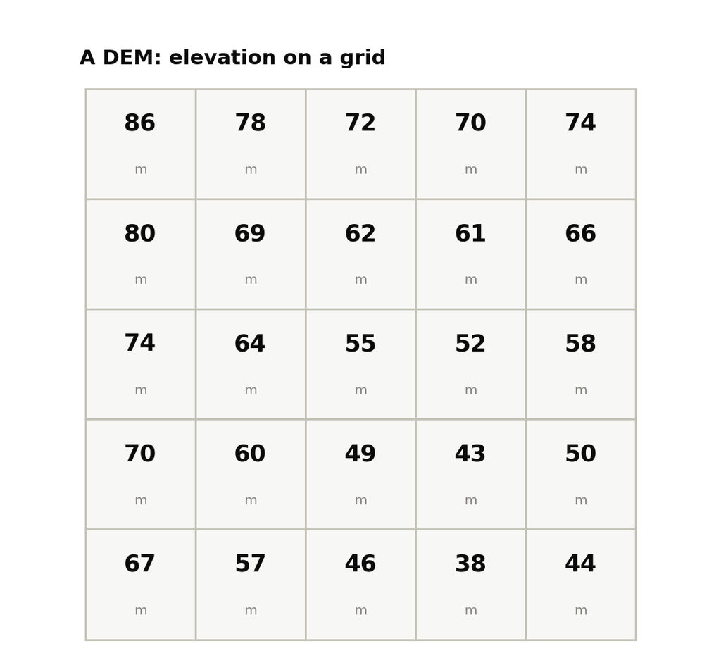

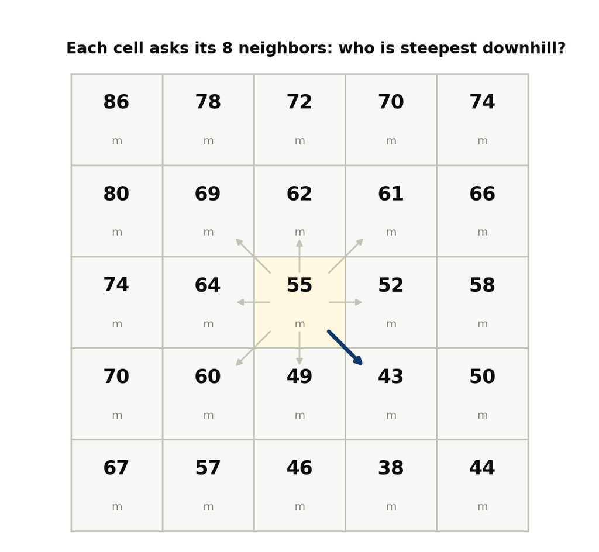

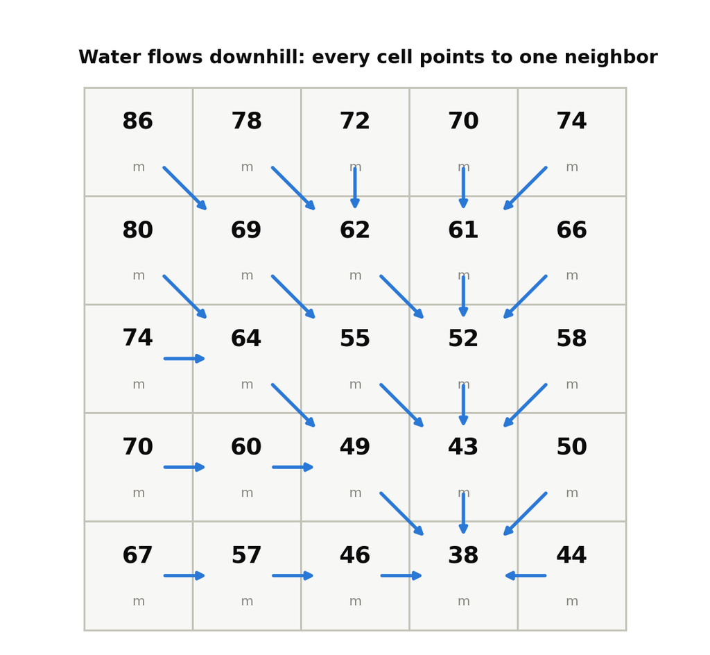

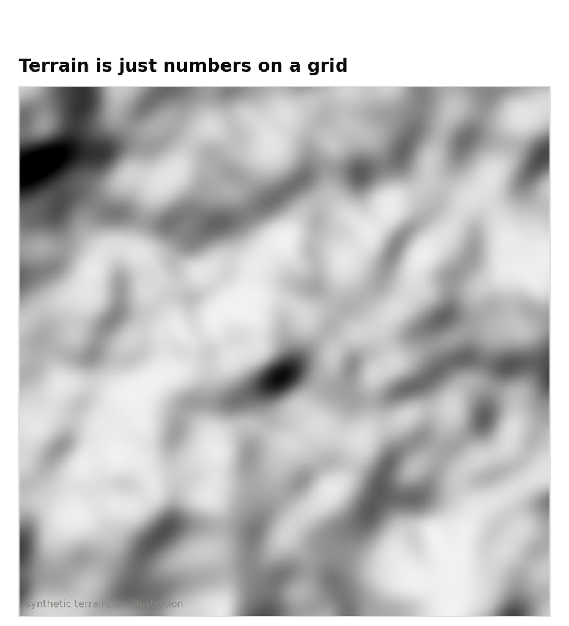

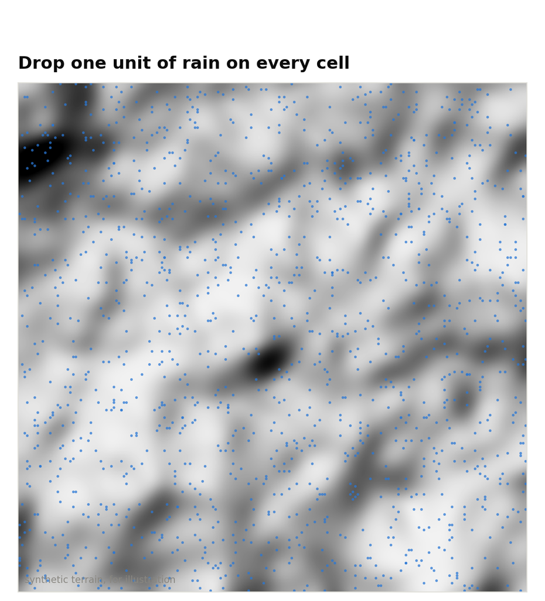

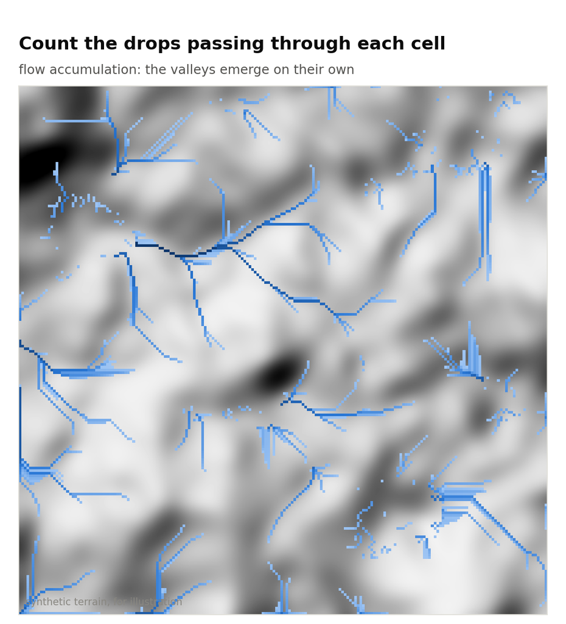

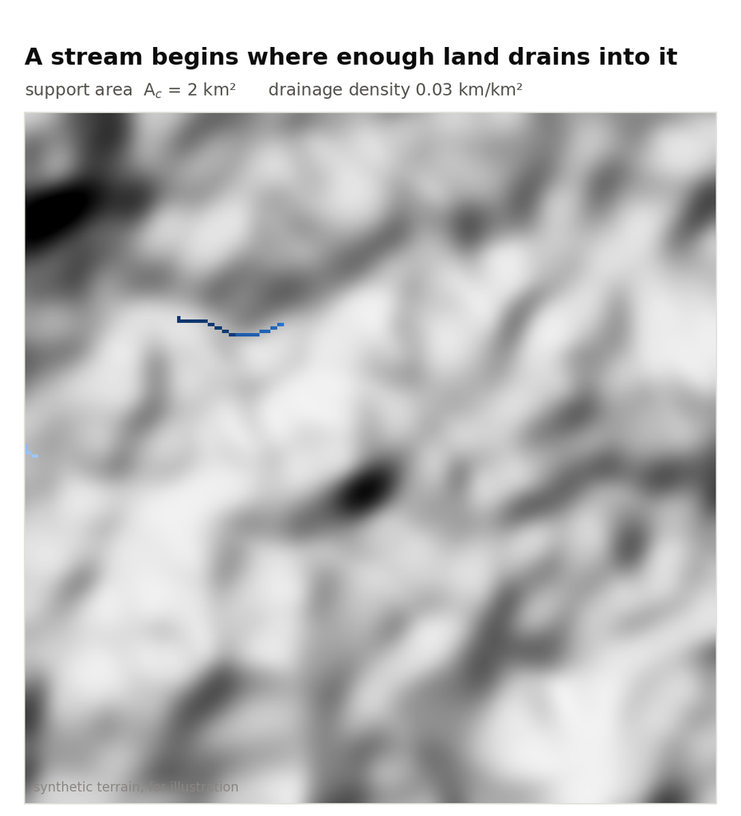

large A<sub>c</sub>, few streams small A<sub>c</sub>, streams everywhere

## Choosing the threshold objectively

A network extracted from a DEM depends on one free parameter, the support area A<sub>c</sub>. The toolkit selects it with the constant stream drop test: in a properly extracted network, first-order streams show the same mean elevation drop as higher-order streams. The sweep takes the first sustained band where the test passes (|t| < 2).

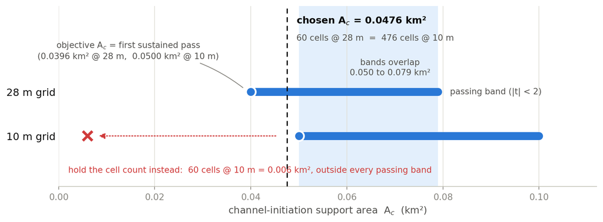

## From channel cells to a network

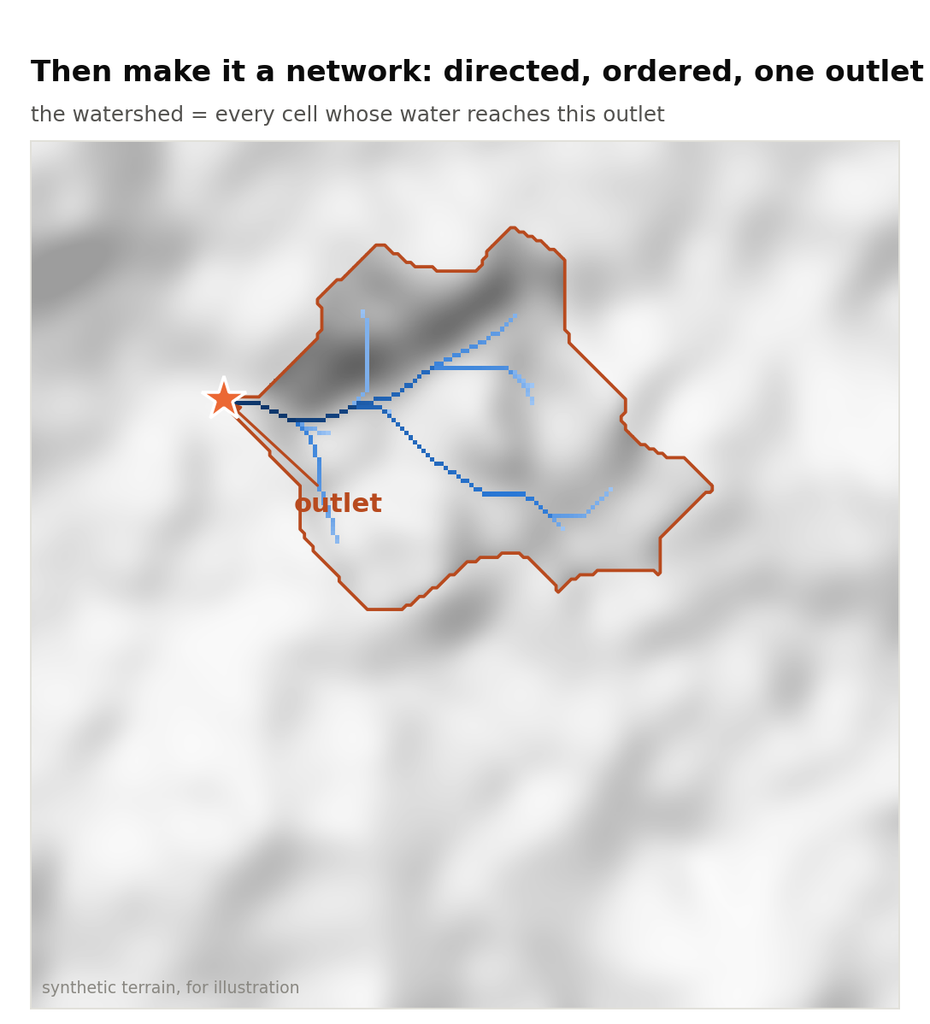

Channel cells are vectorized into segments, directed downstream, ordered from headwaters to outlet, and connected to a single outlet. Each segment carries its length, slope, drainage area, and channel class.

This topology is what routing requires, in DHSVM or any other model. It also supports transport along the network, for temperature, sediment, or nutrients, and connectivity measures for stream ecology.

Distance ties at junctions are resolved by a fixed rule, so the same boundary gives the same network in every run.

## Cleaning up the original workflow

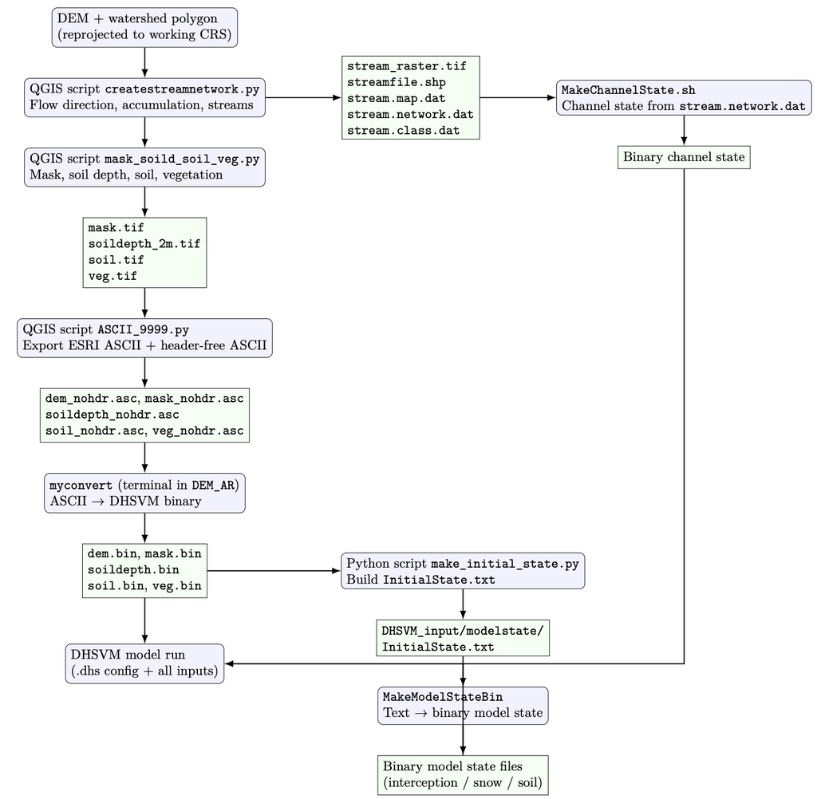

eight steps · three format conversions · GUI required

→

one pipeline · Python + GRASS · headless on the cluster

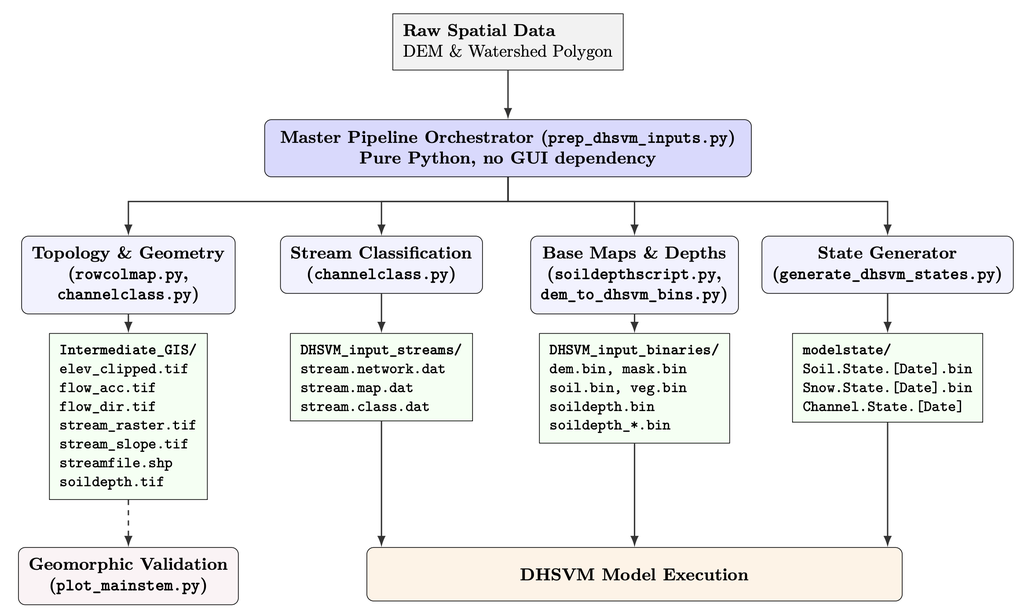

## Running it on the Duke Compute Cluster

```bash
ssh dcc                # dcc-login.oit.duke.edu
git clone https://github.com/waveletswave/DHSVM_Stream_Toolkit_ThatWorks.git
source /hpc/group/abmurraylab/ys451/env.sh
   # Anaconda3, conda env dhsvm_geo, GRASS/7.6.0

export DHSVM_EPSG=32617
export DHSVM_WATERSHED=.../arwd_watershed_UTM17.shp
export DHSVM_DEM_SOURCE=.../AR_src_3dep_10m.tif
export DHSVM_OUT=/work/ys451/cct_demo/outputs_AR_10m
export DHSVM_STREAM_SOURCE_AREA_M2=22000
bash standalone_CA/pipeline/run_pipeline.sh
```

This small basin runs in a login shell; production runs go inside a Slurm allocation.

waveletswave / DHSVM_Stream_Toolkit_ThatWorks

public · MIT license · guides: NEW_WATERSHED_GUIDE · DCC_SETUP

Terrain, stream network, and initial state inputs for DHSVM, from a watershed boundary and a DEM.

```
>>> [1] DEM entry (general: prep_dem)
    valid cells 22849 / 33231
>>> [4] hydrology (GRASS chain)
    22000.0 m2 / cell 100.00 m2 = 220 cells
[stream_network] segments=67  outlets=1
                 max_propagated_order=8
PIPELINE COMPLETE -- DHSVM input set
```

Recorded on dcc-login-05, August 16 (full session log in backup).

## A real basin end to end: AR at 10 m

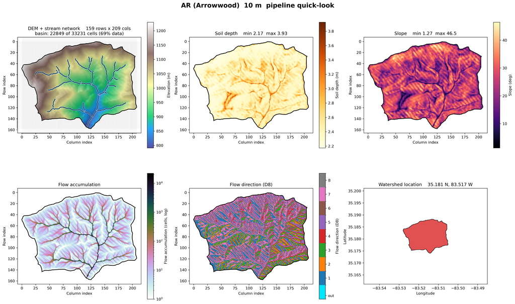

The pipeline’s quick-look for AR (Arrowwood), built from its boundary shapefile at 10 m.

## The same watershed at 30 m

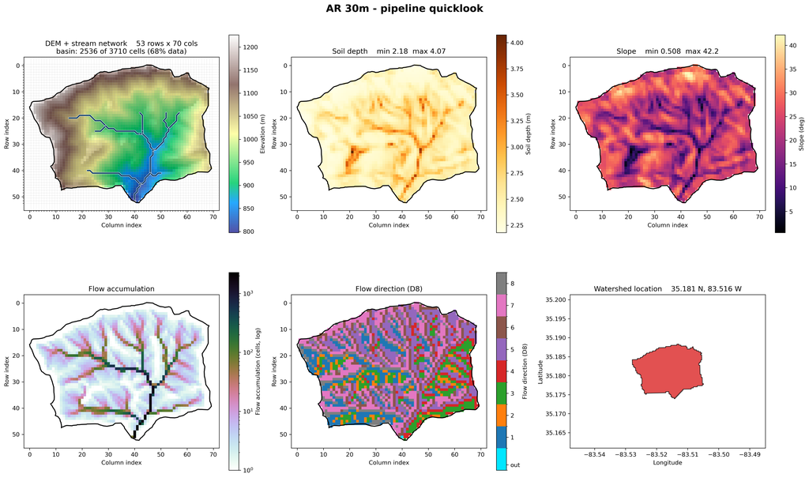

Only the resolution variable changed.

## Validation

Rebuilt against an audited reference implementation, with acceptance criteria fixed before porting: sha256 byte identity for the flat binaries, pixel-level equivalence for the rasters.

STAGE BY STAGE, AGAINST THE REFERENCE

**clip**max |Δ| 0.0

**slope**max |Δ| 0.0

**base grids**sha256 identical

**hydrology**max |Δ| 0.0

**soil depth**1 float32 ULP*documented*

**stream network**2 junction ties*documented*

**model states**sha256 identical

END TO END

NSE 0.99999510

hourly streamflow, 2016 to 2018,  
standalone vs reference

PBIAS −0.000059%

same three years,  
same comparison

identical

skill scores against  
observed streamflow

## Uses beyond DHSVM

Everything upstream of the DHSVM writers is general. Uses I can see directly:

**Stream ecology and habitat.** Network distance, fragmentation, and connectivity, computed from the directed network and its attribute table.

**Water quality and temperature.** A defined downstream order for routing along the channel network.

**Geomorphology and erosion.** Longitudinal profiles, knickpoints, and slope against drainage area from the same rasters.

**Other hydrologic models.** The same terrain and stream products; only a small writer for the target format is needed.

The repository is public under an MIT license and includes a step-by-step guide for a new watershed. I am glad to help anyone who wants to try it on their own basin.

## Summary and thanks

- **February**: scripts inside a **GUI**, on one machine, for one basin
- **Now**: a documented, **validated pipeline**, from a **boundary shapefile** on the **cluster**; two basins, three resolutions, end to end
- **From this fellowship**: **version control**, **validation** against a reference, **batch thinking**, and **floating-point care**

github.com/waveletswave/DHSVM_Stream_Toolkit_ThatWorks

Thank you: Akshay and the CCT, Brad Murray and the lab, and my fellow fellows. I will answer questions in the shared document.

## Backup: the consolidated orchestrator

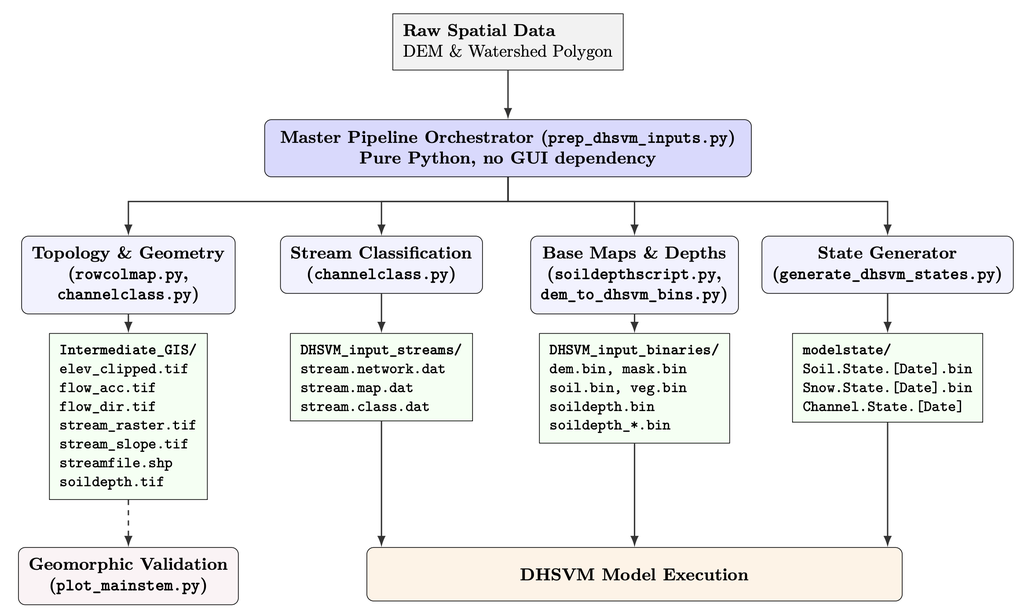

An intermediate stage of the cleanup, drawn for my course report: one orchestrator, four modules, no GUI. The standalone pipeline in the repository descends from this design and removes the remaining QGIS dependency.

## Backup: the full DCC session log

```
(dhsvm_geo) ys451@dcc-login-05  /work/ys451/cct_demo/DHSVM_Stream_Toolkit_ThatWorks $ export DHSVM_DEM_SOURCE=/wo
ork/ys451/dhsvm_ca/standalone_dev/AR_src_3dep_10m.tif
(dhsvm_geo) ys451@dcc-login-05  /work/ys451/cct_demo/DHSVM_Stream_Toolkit_ThatWorks $ export DHSVM_DEM_SOURCE=/work/ys451/dhsvm_ca/standalone_dev/AR_src_3dep_10m.tif

(dhsvm_geo) ys451@dcc-login-05  /work/ys451/cct_demo/DHSVM_Stream_Toolkit_ThatWorks $ export DHSVM_STREAM_SOURCE_
_AREA_M2=22000
(dhsvm_geo) ys451@dcc-login-05  /work/ys451/cct_demo/DHSVM_Stream_Toolkit_ThatWorks $ export DHSVM_STREAM_SOURCE_AREA_M2=22000

(dhsvm_geo) ys451@dcc-login-05  /work/ys451/cct_demo/DHSVM_Stream_Toolkit_ThatWorks $ bash standalone_CA/pipeline
e/run_pipeline.sh
(dhsvm_geo) ys451@dcc-login-05  /work/ys451/cct_demo/DHSVM_Stream_Toolkit_ThatWorks $ bash standalone_CA/pipeline/run_pipeline.sh

==========================================================
  STANDALONE DHSVM PREPROCESSING PIPELINE
  OUT = /work/ys451/cct_demo/outputs_AR_10m
==========================================================

>>> [1] DEM entry (general: prep_dem)
    prep_dem /work/ys451/dhsvm_ca/standalone_dev/AR_src_3dep_10m.tif -> elev_clipped.tif  (res 10 m)
target: EPSG:32617  10.000 m  159 rows x 209 cols  (pad 0 cells)
extent (EPSG:32617): (269800.0, 3895230.0, 271890.0, 3896820.0)
source: EPSG:5070  351x309  res~(9.119545, 9.119545)  nodata=nan
wrote /work/ys451/cct_demo/outputs_AR_10m/elev_clipped.tif
  valid cells 22849 / 33231  (nodata 10382)
  elev range 791.2 .. 1229.9 m

>>> [2] slope (GRASS r.slope.aspect)
Default locale not found, using UTF-8
Default locale settings are missing. GRASS running with C locale.Starting GRASS GIS...
Creating new GRASS GIS location <gslope_908810>...
Executing <g.version> ...
GRASS 7.6.0 (2019)
Execution of <g.version> finished.
Cleaning up temporary files...
Default locale not found, using UTF-8
Default locale settings are missing. GRASS running with C locale.Starting GRASS GIS...
Executing <r.in.gdal input=/work/ys451/cct_demo/outputs_AR_10m/elev_clipped.tif output=elev_clipped --overwrite> ...
Importing raster map <elev_clipped>...  ... 100%
Execution of <r.in.gdal input=/work/ys451/cct_demo/outputs_AR_10m/elev_clipped.tif output=elev_clipped --overwrite> finished.
Cleaning up temporary files...
```

[output cut: 286 more lines]

```
soildepth_uniform_3.0m.bin
soildepth_uniform_3.5m.bin
soildepth_uniform_4.0m.bin
veg.bin

/work/ys451/cct_demo/outputs_AR_10m/DHSVM_input_streams:
stream.class.dat
stream.map.dat
stream.network.dat

/work/ys451/cct_demo/outputs_AR_10m/modelstate:
Channel.State.01.01.2016.00.00.00
(dhsvm_geo) ys451@dcc-login-05  /work/ys451/cct_demo/DHSVM_Stream_Toolkit_ThatWorks $ exitexit

exit
```

Recorded with script on dcc-login-05, August 16. Scroll inside the box.